# HW Day 1

Mai Ng

August 3, 2018

## Setup

```r
library(dplyr)
```

```r
library(readr)
library(tidyr)
library(ggplot2)
library(lubridate)
df <- read.csv("/Users/mainguyen/Downloads/MonthlyRainfall_mm_ByProvince.csv", header=TRUE, sep=",")
```

## Explore data

```r
summary(df)
```

```
##       Year          Province       May             June
##  Min.   :2006   Bai Chay:11   Min.   :  4.5   Min.   :  1.2
##  1st Qu.:2008   Ca Mau  :11   1st Qu.: 92.4   1st Qu.: 69.0
##  Median :2011   Da Lat  :11   Median :166.7   Median :163.0
##  Mean   :2011   Da Nang :11   Mean   :175.0   Mean   :177.9
##  3rd Qu.:2014   Ha Noi  :11   3rd Qu.:249.2   3rd Qu.:252.1
##  Max.   :2016   Hue     :11   Max.   :491.0   Max.   :628.0
##                 (Other) :99
##       July            Aug.            Sep.             Oct.
##  Min.   :  4.7   Min.   :  1.4   Min.   :  44.9   Min.   :   4.0
##  1st Qu.:113.8   1st Qu.:146.7   1st Qu.: 169.0   1st Qu.:  87.7
##  Median :219.5   Median :236.8   Median : 254.0   Median : 192.4
##  Mean   :253.4   Mean   :261.4   Mean   : 305.9   Mean   : 282.5
##  3rd Qu.:357.3   3rd Qu.:353.6   3rd Qu.: 379.1   3rd Qu.: 377.7
##  Max.   :900.5   Max.   :866.2   Max.   :1375.7   Max.   :1544.0
##
##       Nov.
##  Min.   :   0.0
##  1st Qu.:  34.8
##  Median :  88.9
##  Mean   : 203.6
##  3rd Qu.: 272.4
##  Max.   :1511.2
##
```

```r
df_long <- gather(df, "month", "rain_fall", 3:9)
```

```r
table(df_long$month)
```

```
##
## Aug. July June  May Nov. Oct. Sep.
##  165  165  165  165  165  165  165
```

```r
## Reformate month
df_long$month <- factor(df_long$month,
                        levels=c("May", "June", "July", "Aug.", "Sep.", "Oct.", "Nov."),
                        labels=c("May", "Jun", "Jul", "Aug", "Sep", "Oct", "Nov")
)

## Create a mon year var
df_long$mon_num <- ifelse(df_long$month == "May", "05-01",
                          ifelse(df_long$month == "Jun", "06-01",
                                 ifelse(df_long$month == "Jul", "07-01",
                                        ifelse(df_long$month == "Aug", "08-01",
                                               ifelse(df_long$month == "Sep", "09-01",
                                                      ifelse(df_long$month == "Oct", "10-01",
                                                             ifelse(df_long$month == "Nov", "11-01", "Others"
                                                             )
                                                      )
                                               )
                                        )
                                 )
                          )
)
df_long$mon_year <- paste0(df_long$Year, "-", df_long$mon_num)
df_long$monyear <- format(as.Date(df_long$mon_year), "%Y-%m")

## Refactor Provinces' names
df_long$Province <- factor(df_long$Province, levels=c("Lai Chau", "Tuyen Quang", "Son La",
                                                      "Ha Noi", "Bai Chay", "Nam Dinh",
                                                      "Vinh", "Hue", "Da Nang",
                                                      "Qui Nhon", "Playku", "Da Lat",
                                                      "Nha Trang", "Vung Tau", "Ca Mau")
)
```

## Visualizing

### Plot 1

**Seem like dry season is becoming drier as October now has less rain than before**

**In dry season, we also see a larger gap in precipitation among provinces**

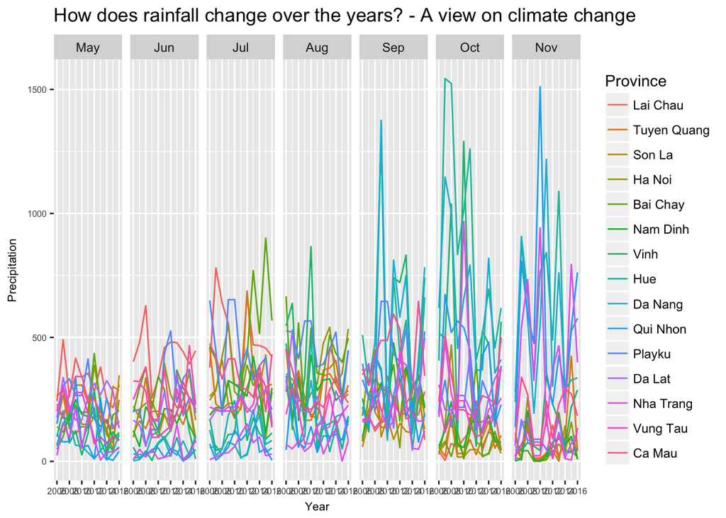

```r
# color_palette <- c("#000000","#004949","#009292","#ff6db6","#ffb6db",
#  "#490092","#006ddb","#b66dff","#6db6ff","#b6dbff",
#  "#920000","#924900","#db6d00","#24ff24","#ffff6d")
month_change <- ggplot(df_long, aes(x=Year, y=rain_fall, colour=Province)) +
  geom_line() +
  #geom_point(size=1.5, shape=20) +
  #geom_hline(yintercept=100, color = "red", size=1.5) +
  facet_wrap(~month, ncol=7) +
  ggtitle("How does rainfall change over the years? - A view on climate change") +
  #theme(text = element_text(size = 16, family="Helvetica", face="italic")) +
  theme_grey() +
  labs(y = "Precipitation", colour="Province") +
  theme(axis.title.x = element_text(size = 8)) +
  theme(axis.title.y = element_text(size = 8)) +
  theme(axis.text.x = element_text(size = 6)) +
  theme(axis.text.y = element_text(size = 6))
  #scale_colour_brewer(palette=color_palette)
month_change
```

### Plot 2

**As, I can see there should be some changes in rainfall, I take a look at the trend in total rainfall in each month over the years**

**It is quite interesting to see following a month with much rain is a month with less rain and vice versa**

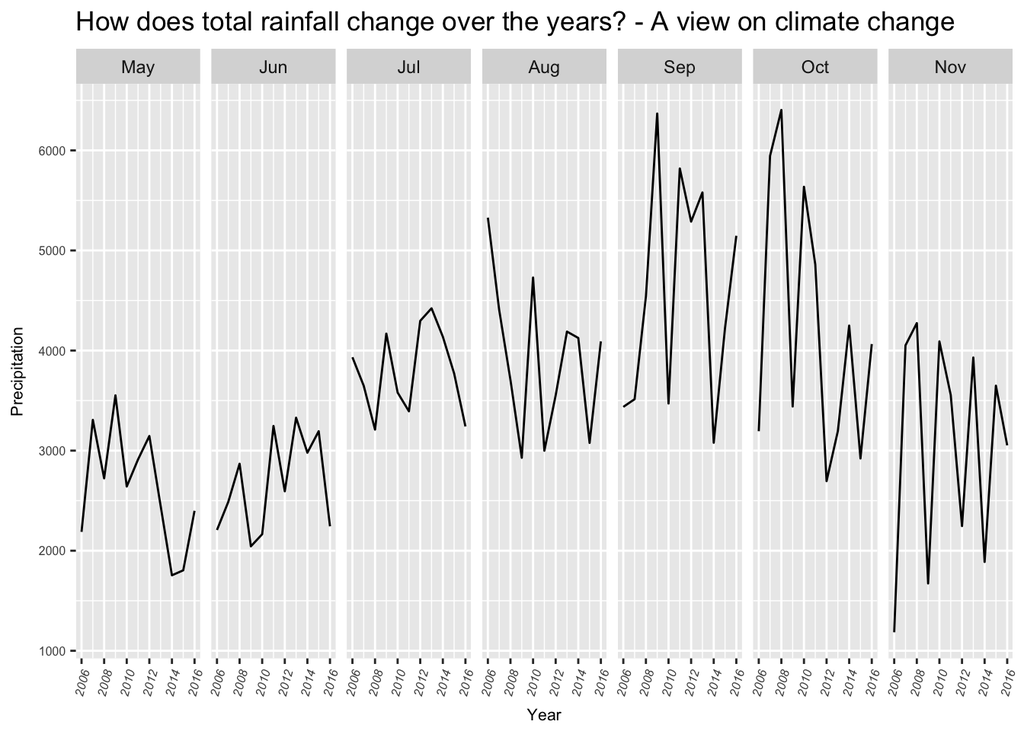

```r
df_long_cal <- df_long %>%
  group_by(Year, month) %>%
  summarise(total=sum(rain_fall),
          avg=mean(rain_fall))

total_change <- ggplot(df_long_cal, aes(x=Year, y=total)) +
  geom_line() +
  facet_wrap(~month, ncol=7) +
  ggtitle("How does total rainfall change over the years? - A view on climate change") +
  #theme(text = element_text(size = 16, family="Helvetica", face="italic")) +
  theme_grey() +
  labs(y = "Precipitation") +
  theme(axis.title.x = element_text(size = 8)) +
  theme(axis.title.y = element_text(size = 8)) +
  theme(axis.text.x = element_text(angle = 75, hjust=1, face = "italic", size = 6)) +
  theme(axis.text.y = element_text(size = 6))
  #scale_colour_brewer(palette=color_palette)
total_change
```

### Plot 3

**I also want to see a distinction among provinces**

*Pls note that: The data only covers May to Nov*

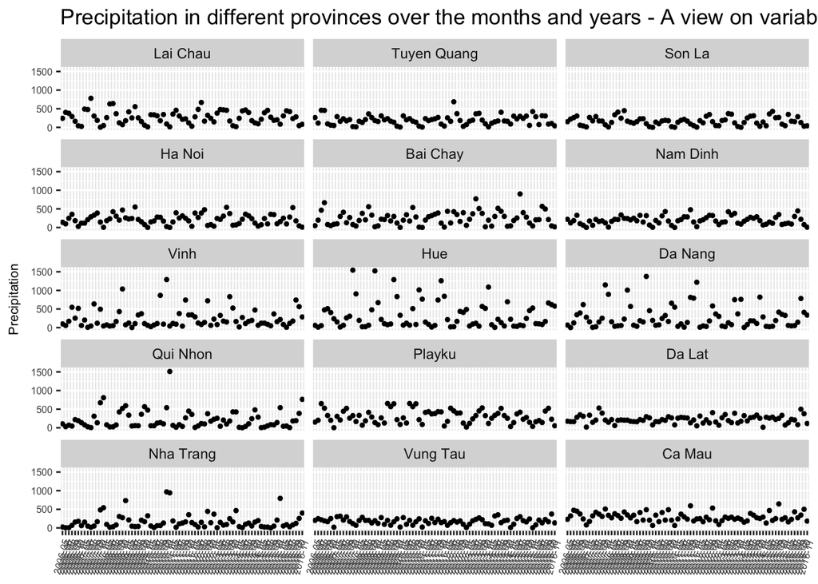

```r
prov_change <- ggplot(df_long, aes(x=monyear, y=rain_fall)) +
  #geom_line() +
  geom_point(size=1.5, shape=20) +
  #geom_vline(xintercept=which(as.month(df_long$monyear), nchar(df_long$monyear)-1, nchar(df_long$monyear))=="05"), color = "red", linetype="dashed", size=1.5) +
  facet_wrap(~Province, ncol=3) +
  ggtitle("Precipitation in different provinces over the months and years - A view on variability") +
  theme_grey() +
  labs(y = "Precipitation", colour="Province") +
  theme(axis.title.x = element_blank()) +
  theme(axis.title.y = element_text(size = 8)) +
  theme(axis.text.x = element_text(angle = 75, hjust=1, face = "italic", size = 6)) +
  theme(axis.text.y = element_text(size = 6))

prov_change
```

## Next step

**1. Map with the reality: Is there any natural events to back up my findings? Eg. Typhoon, Flood, Drought, etc.**

**2. I am curious to know the correlation between rainfall and the gap in highest and lowest quintile However, I face some challenges:** *- Quintile income index is annual, while rainfall data is monthly. I will need to choose the representative figure for rainfall index. Should it be mean, median…?*

*- Rainfall data only covers from May to Nov. Would this be sufficient for me infer?*

**Therefore, I decided to leave this as a question for further investigation.**